# Chapter 8: Risk and Return

FINA 3000 · Business Finance I · Class 12

Dr. Justin Mohr

October 1, 2026

## Our new mantra

- Return is a reward for risk
- Return is a reward for risk
- Return is a reward for risk
- Return is a reward for risk
- Return is a reward for risk

## Can I get a high return without risk?

- NO!!!

## Our old friend

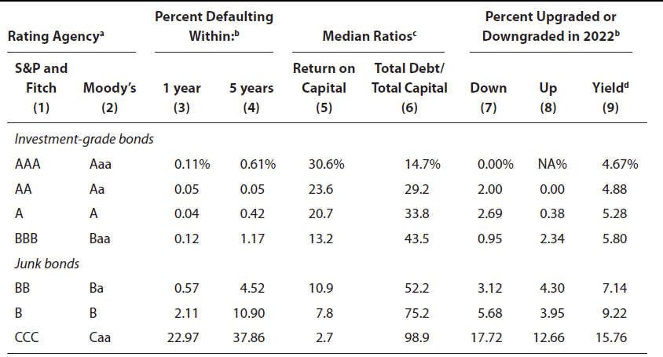

## Is that too good to be true?

- Why do we think that this kind of deal is too good to be true?
- If there is such little risk, why is every investors not trying to get in?
  - This would cause the interest rate to go down!
- An alternative, they might be lying about their risk and hoping that the return doesn’t make you ask many questions.

## SEC vs LOPEZ, MEHR, BURKENROAD

- The SEC alleges:
  - From approximately April 2020 through November 2022 Defendants raised approximately $112 million combined from hundreds of investors through fraudulent offerings from retail investors across the United States through the fraudulent offer and sale of securities
  - REV’s primary business was purchasing distressed retail companies with name brand recognition and converting them into e-commerce only businesses
    - ETC Pier 1 Imports Online, Inc., RadioShack Online, LLC
- During the Relevant Period, Defendants sold securities in the form of unsecured notes promising up to 25% annualized returns as well as equity (membership units) with a monthly preferential dividend as high as 2.083%.
  - https://www.sec.gov/files/litigation/complaints/2025/comp26413.pdf

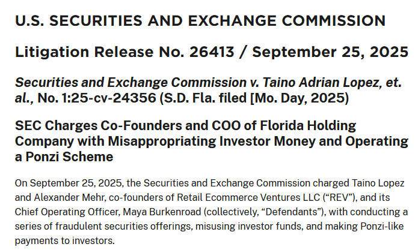

## An alleged deal

- Voidzilla: https://pro.smartplayer.video/play.php?vid=9a34e313-60b0-49e8-bfea-37127d3eaa22 Start 1:30

## You already know how to value that risk!

- This was a bond deal!
- You know what the yield on debt should be for given risk!!

## Stand- Alone Risk

- The risk that an investor faces if they hold only one asset
- Key measures/items
  - Return Distributions
  - Expected Return\Past Return
  - Standard deviation $\sigma$
  - Coefficient of variation
  - Sharpe Ratio

## Expected Return

- This is the return that you expect to earn if you own this financial product
- We do not know the future!
- So we often use historical data to try and predict the future return

## Justin’s Cupcakes

After doing some forecasting, we have projected three states of the world and three expected returns for Justin’s cupcakes. What is the expected return?

Justin’s Cupcakes: three states of the world

| Economy/State | Probability | Rate of Return |
| --- | --- | --- |
| Great | 0.3 | 80% |
| Normal | 0.4 | 10% |
| Bad | 0.3 | -60% |

## Taylor’s Cupcakes

After doing some forecasting, we have projected three states of the world and three expected returns for Taylor’s cupcakes. What is the expected return?

Taylor’s Cupcakes: the same three states, a much narrower spread

| Economy/State | Probability | Rate of Return |
| --- | --- | --- |
| Great | 0.3 | 15% |
| Normal | 0.4 | 10% |
| Bad | 0.3 | 5% |

## Risk

- What are we concerned about?
  - Losing our capital
- Those are two very different distributions of return!
- Any idea which you would prefer?
  - No wrong answers!

## How do we measure risk?

- Standard Deviation
  - How familiar are we?
- The variability of a set of observations
  - How spread out the observations are
- Return distribution that is clustered close together
  - Low standard deviation
- Return distribution that is spread out
  - High standard deviation

## Justin’s Cupcakes

After doing some forecasting, we have projected three states of the world and three expected returns for Justin’s cupcakes. What is the standard deviation?

Justin’s Cupcakes: three states of the world

| Economy/State | Probability | Rate of Return |
| --- | --- | --- |
| Great | 0.3 | 80% |
| Normal | 0.4 | 10% |
| Bad | 0.3 | -60% |

## Taylor’s Cupcakes

After doing some forecasting, we have projected three states of the world and three expected returns for Taylor’s cupcakes. What is the expected standard deviation?

Taylor’s Cupcakes: the same three states, a much narrower spread

| Economy/State | Probability | Rate of Return |
| --- | --- | --- |
| Great | 0.3 | 15% |
| Normal | 0.4 | 10% |
| Bad | 0.3 | 5% |

## Distributions

- Which do you prefer a stock with 10% expected return and a sd of 3% or a 10% expected return with a 54% sd?
- Let’s build distributions.

- But we can quantify this.
- The 68–95–99.7 rule
  - 68% of outcomes land within 1 standard deviation of the mean
  - 95% land within 2
  - 99.7% land within 3

## LMARK

LMARK has an expected return of 11.00% and a standard deviation of 17.00%. Assuming returns are normally distributed.

What range contains approximately 68% of outcomes?

What range holds about 95%?

## Coefficient of Variation

Risk per unit of return

$$\frac{\sigma}{\hat{r}}$$

- Justin’s Cupcakes 54.22/10=5.42
- Taylor’s Cupcakes 3.87/10=0.39
- For a percent of return, how much risk must we accept for each?
- Which do you prefer?

## Sharpe Ratio

- Return for unit of risk

$$\frac{\hat{r} - r_f}{\sigma}$$

- Assuming rf of 4%
- Justin’s Cupcakes (10%-4%)/54.22%=0.11
- Taylor’s Cupcakes (10%-4%)/3.87% =1.55
- Which gives you more return for a unit of risk?

## Risk Aversion

- Most investors are risk averse
  - That is they dislike risk and need a higher return to buy risky securities
- What would you need to buy Justin’s cupcakes?
- A higher return!
- Riskier securities must have higher returns than less risky securities
  - If they do not, then buying and selling will occur
- This is why you should be suspicious of high return and low risk

## Portfolios

- Owning one stock is not good.
- We want to limit our sources of risk!
- That’s why we buy many stocks
- If you buy enough then you own the market portfolio

## Diversification

- If we own many stocks then we can minimize our risk exposure to company specific risks.
- If I have 2000 firms in my portfolio, the arrest of a firm’s CEO won’t impact me that much
- The goal is to have as little risk concentration as possible
- Why is it a bad idea to own your employers stock?

## What risks are priced?

- Investors then shouldn’t price risks that are company-specific
  - They can be diversified away
  - (Other investors do not need to be compensated for them)
- What risks are left?
- Market risks
  - Things I cannot get away from!
  - War, economy, inflation
- If this is true, then investors do not need to be rewarded for diversifiable risk. Only the market risk. Why?

## Preview: CAPM/SML

- Simplified Mechanism: The only risk that is priced is shared with the market.
  - No pricing of diversifiable risk.

$$r_i - r_f = \beta \ast \left( r_m - r_f \right) \rightarrow RP_i = \beta \ast RP_m \rightarrow r_i = r_f + \beta \ast RP_m$$

- Then what does beta mean?
  - Perfectly correlated with the market.

$$\beta = 1$$

$$\beta = 2 \text{ , } \beta = -1$$

## Practice

Two stocks over five states of the world

| Probability | Stock A | Stock B |
| --- | --- | --- |
| 0.1 | (10%) | (35%) |
| 0.2 | 2% | 0% |
| 0.4 | 12% | 20% |
| 0.2 | 20% | 25% |
| 0.1 | 38% | 45% |

- The risk free rate is 2.5%
- Calculate the expected rate of return, standard deviation for stock A
- Also the coefficient of variance, and Sharpe ratio for each stock
- Standard deviation of Stock B is 20.35%

$$\sigma = \sqrt{\sum \left( r_i - \hat{r} \right)^2 \ast P_i}$$

## Upcoming Dates

Upcoming class dates and deadlines

| Date | Topic | Due / Notes |
| --- | --- | --- |
| Sun Oct 4 | MindTap Ch 7 | HW DUE |
| Tue Oct 6 | Chapter 8: Risk and Return | - |
| Thu Oct 8 | Chapter 9: Stocks (part 1) | - |
| Sun Oct 11 | MindTap Ch 8 | HW DUE |

**Office:** 325 Holman Hall · **Office hours:** T TH 10:50A-12:20P · jjmohr1@olemiss.edu